# Code_template_normalized

Victoria Rios

12/4/2021

#Análisis de datos de BRCA TN TCGA

Primero definimos la opción para no se lean los strings como factores.

```r
options(stringsAsFactors = F)
```

Primero leemos los datos clínicos.

```r
brca_clin <- read.delim(file = "BRCA.clin.merged.txt", sep = "\t", header = F,
row.names = 1, as.is = T)
```

Obtenemos los datos para los 3 receptores en los renglones 24, 29 y 1160.

```r
print(rownames(brca_clin)[c(24,29,1160)])
```

```
## [1] "patient.breast_carcinoma_estrogen_receptor_status"
## [2] "patient.breast_carcinoma_progesterone_receptor_status"
## [3] "patient.lab_proc_her2_neu_immunohistochemistry_receptor_status"
```

Índices de muestras triple negativo (TN)

```r
index_TN <- which(as.character(brca_clin[24,]) == "negative" &
as.character(brca_clin[29,]) == "negative" &
as.character(brca_clin[1160,]) == "negative")
```

Filtramos para tener datos sólo de los TN y obtenemos las claves de las muestras

```r
brca_clin <- brca_clin[,index_TN]
tn_samples <- toupper(as.character(brca_clin[21,]))
```

Leer datos de RNA-seq

```r
f <- "BRCA.rnaseqv2__illuminahiseq_rnaseqv2__unc_edu__Level_3__RSEM_genes_normalized__data.data.txt"
brca_rnaseq <- read.delim(file = f, sep="\t", as.is=T, row.names = 1)
brca_rnaseq <- data.matrix(brca_rnaseq[-1,])
```

Extraer gene symbols

```r
gene_symbols <- as.character(sapply(rownames(brca_rnaseq), function(x)
unlist(strsplit(x = x, split = "\\|"))[1]))
```

Eliminar renglones con gene symbol igual a “?”

```r
brca_rnaseq <- brca_rnaseq[which(gene_symbols != "?"),]
gene_symbols <- gene_symbols[which(gene_symbols != "?")]
```

Ver el tipo de muestra de acuerdo al TCGA barcode y quitar los normales (tipo “11”) https://docs.gdc. cancer.gov/Encyclopedia/pages/TCGA_Barcode/

```r
sample_type <- substr(x = colnames(brca_rnaseq), start = 14, stop = 15)
brca_rnaseq <- brca_rnaseq[,-which(sample_type == "11")]
sample_type <- sample_type[-which(sample_type == "11")]
```

Hacer match entre las muestras TN y los de RNAseq

```r
tn_match <- match(gsub(pattern = "-", replacement = "\\.", x = tn_samples),
substr(x = colnames(brca_rnaseq), start = 1, stop = 12))
tn_match_na <- which(is.na(tn_match))
brca_clin <- brca_clin[,-tn_match_na]
tn_samples <- tn_samples[-tn_match_na]
tn_match <- tn_match[-tn_match_na]
brca_rnaseq <- brca_rnaseq[,tn_match]

brca_rnaseq_t <- t(brca_rnaseq) # Transpose of Rnaseq
```

# Normalization of the dataset

```r
brca_rnaseq_n <- log2(brca_rnaseq_t + 1)
```

# Clustering PCA results (normalized)

## PCA

```r
# Principal components
x <- prcomp(brca_rnaseq_n, scale = FALSE)
```

```r
library(factoextra)
```

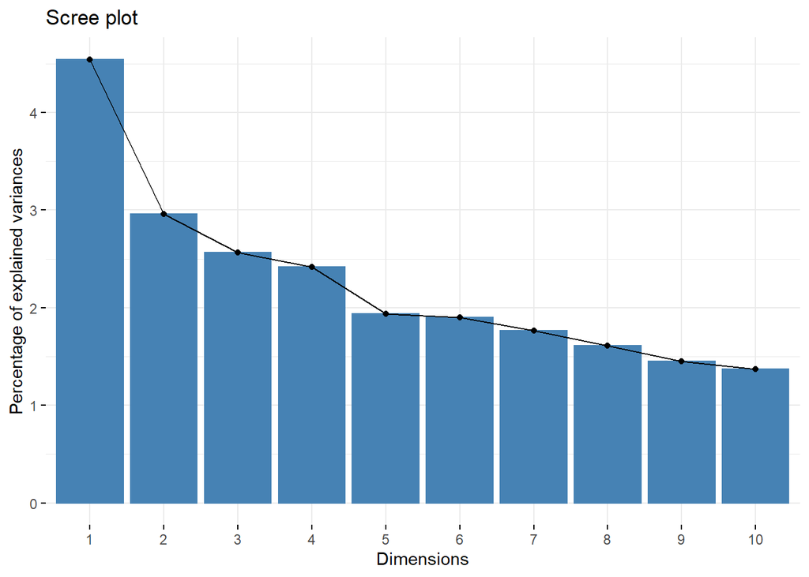

```r
#Visualize eigenvalues (scree plot). Show the percentage of variances explained by each principal component.
fviz_eig(x)
```

## Graph of individuals. Individuals with a similar profile are grouped together.

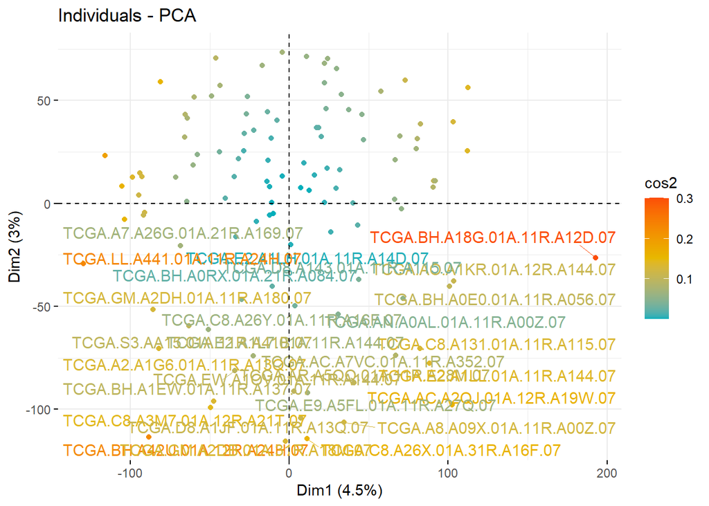

```r
fviz_pca_ind(x,
             col.ind = "cos2", # Color by the quality of representation
             gradient.cols = c("#00AFBB", "#E7B800", "#FC4E07"),
             repel = T,     # Avoid text overlapping,
             max.overlaps = Inf
             )
```

## Re-labeling the patients IDs

```r
# We check that the patient ID doesn't repeat
temp <- table(x[["x"]])

isTRUE(any(temp > 1)) # if the result is FALSE, they appear only once
```

```
## [1] FALSE
```

We save the original IDs in another list inside of x

```r
orig_IDs <- matrix(row.names(x[["x"]]), ncol = 1) # we store the original IDs
short_IDs <- as.character(matrix(data = 1:nrow(x[["x"]]), ncol = 1)) # we store the short IDs

IDs <- cbind(orig_IDs, short_IDs) # we bind them in the same matrix


x[["IDs"]] <- IDs # We append the new IDs matrix to the x list
```

We proceed to assign a unique number to each patient

```r
row.names(x[["x"]]) <- short_IDs

head(x[["x"]])
```

```
##         PC1       PC2        PC3      PC4        PC5      PC6          PC7
## 1 -34.77630 12.851299  -19.74839 18.66707 -53.942113 21.15655  -33.2286425
## 2 -12.48833 -5.735631   84.85662 39.09367  -9.645538 10.33063   -0.5714474
## 3 -71.44650 12.818727  -81.06502 87.20191 -28.064658 21.16727   -1.6607350
## 4  29.69381 65.406327  -36.24245 21.87599  84.784312  5.07634  -25.7076986
## 5 -28.63871 25.416391 -119.88952 93.92394 -13.944131 11.98572 -122.6576637
## 6  80.07158 26.603180  -79.45512 17.69526  53.746263 27.90487  -19.2740806
##           PC8        PC9       PC10      PC11       PC12       PC13        PC14
## 1  32.4255610 -26.015145  21.572180 -17.39858  13.857970 -10.217833  35.6784286
## 2  39.0788690   8.555215 -33.890396 -36.53837 -43.722354 -35.173244   1.9950241
## 3   5.0074069 -24.549684   5.313364 -23.95346   4.399015  -8.152651  -9.0925930
## 4 -45.2112843   5.468948 -38.422196  20.64253   2.284226 -77.590106 -38.1949562
## 5 -19.4385870 -33.928770  47.551929   3.47101  19.248899   9.476779   0.1937712
## 6   0.5597773  11.351354  28.290620  60.66396  32.250652 -71.003925  39.7496354
##         PC15        PC16       PC17       PC18      PC19       PC20      PC21
```

[output cut: 104 more lines]

We plot again to visualize the short IDs of each patient

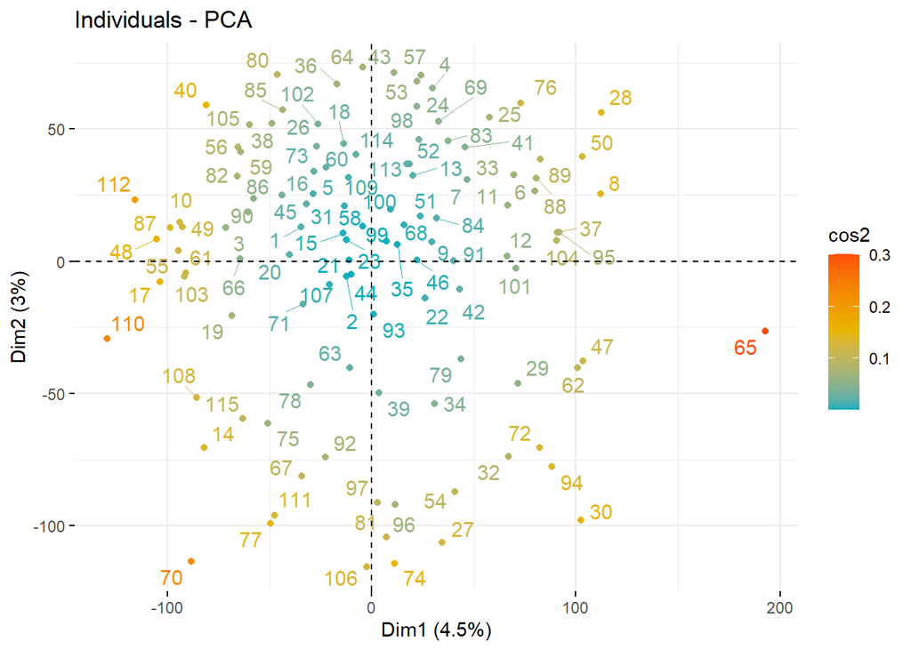

```r
fviz_pca_ind(x,
             col.ind = "cos2", # Color by the quality of representation
             gradient.cols = c("#00AFBB", "#E7B800", "#FC4E07"),
             repel = T,     # Avoid text overlapping,
             max.overlaps = Inf
             )
```

## Graph of variables.

Positive correlated variables point to the same side of the plot. Negative correlated variables point to opposite sides of the graph.

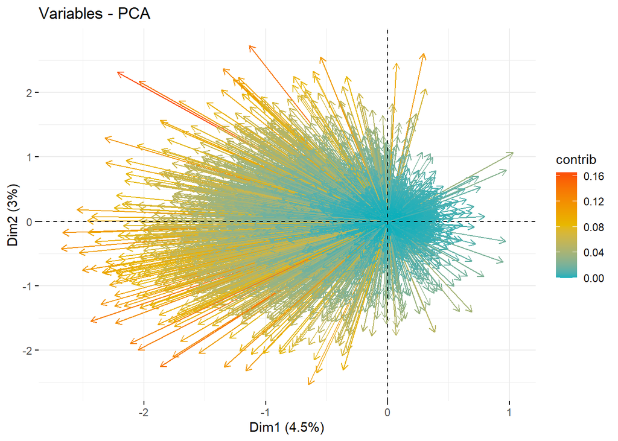

```r
fviz_pca_var(x,
             col.var = "contrib", # Color by contributions to the PC
             gradient.cols = c("#00AFBB", "#E7B800", "#FC4E07"),
             repel = TRUE     # Avoid text overlapping
             )
```

## Biplot of individuals and variables

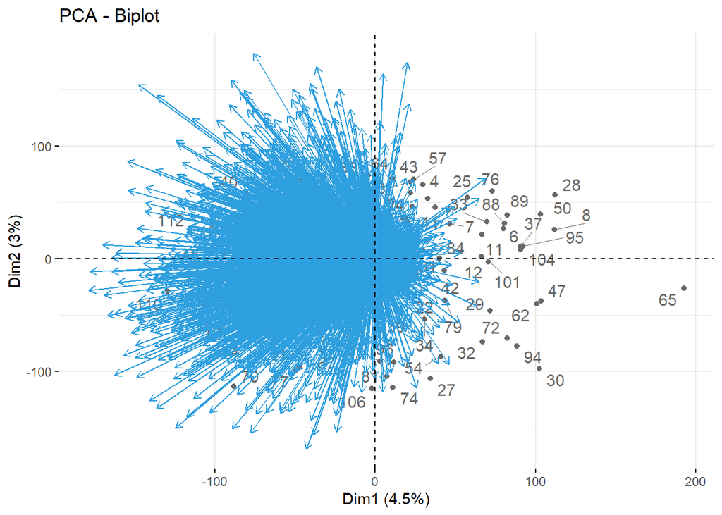

```r
fviz_pca_biplot(x, repel = TRUE,
                col.var = "#2E9FDF", # Variables color
                col.ind = "#696969"  # Individuals color
                )
```

## K-means with PCA results ——————————————————————–

```r
# Coordinates of individuals
ind.coord <- as.data.frame(get_pca_ind(x)$coord)

head(ind.coord)
```

```
##       Dim.1     Dim.2      Dim.3    Dim.4      Dim.5    Dim.6        Dim.7
## 1 -34.77630 12.851299  -19.74839 18.66707 -53.942113 21.15655  -33.2286425
## 2 -12.48833 -5.735631   84.85662 39.09367  -9.645538 10.33063   -0.5714474
## 3 -71.44650 12.818727  -81.06502 87.20191 -28.064658 21.16727   -1.6607350
## 4  29.69381 65.406327  -36.24245 21.87599  84.784312  5.07634  -25.7076986
## 5 -28.63871 25.416391 -119.88952 93.92394 -13.944131 11.98572 -122.6576637
## 6  80.07158 26.603180  -79.45512 17.69526  53.746263 27.90487  -19.2740806
##         Dim.8      Dim.9     Dim.10    Dim.11     Dim.12     Dim.13      Dim.14
## 1  32.4255610 -26.015145  21.572180 -17.39858  13.857970 -10.217833  35.6784286
## 2  39.0788690   8.555215 -33.890396 -36.53837 -43.722354 -35.173244   1.9950241
## 3   5.0074069 -24.549684   5.313364 -23.95346   4.399015  -8.152651  -9.0925930
## 4 -45.2112843   5.468948 -38.422196  20.64253   2.284226 -77.590106 -38.1949562
## 5 -19.4385870 -33.928770  47.551929   3.47101  19.248899   9.476779   0.1937712
## 6   0.5597773  11.351354  28.290620  60.66396  32.250652 -71.003925  39.7496354
##       Dim.15      Dim.16     Dim.17     Dim.18    Dim.19     Dim.20    Dim.21
```

[output cut: 104 more lines]

# Let’s find the optimal K value for our data

# 1. Elbow method

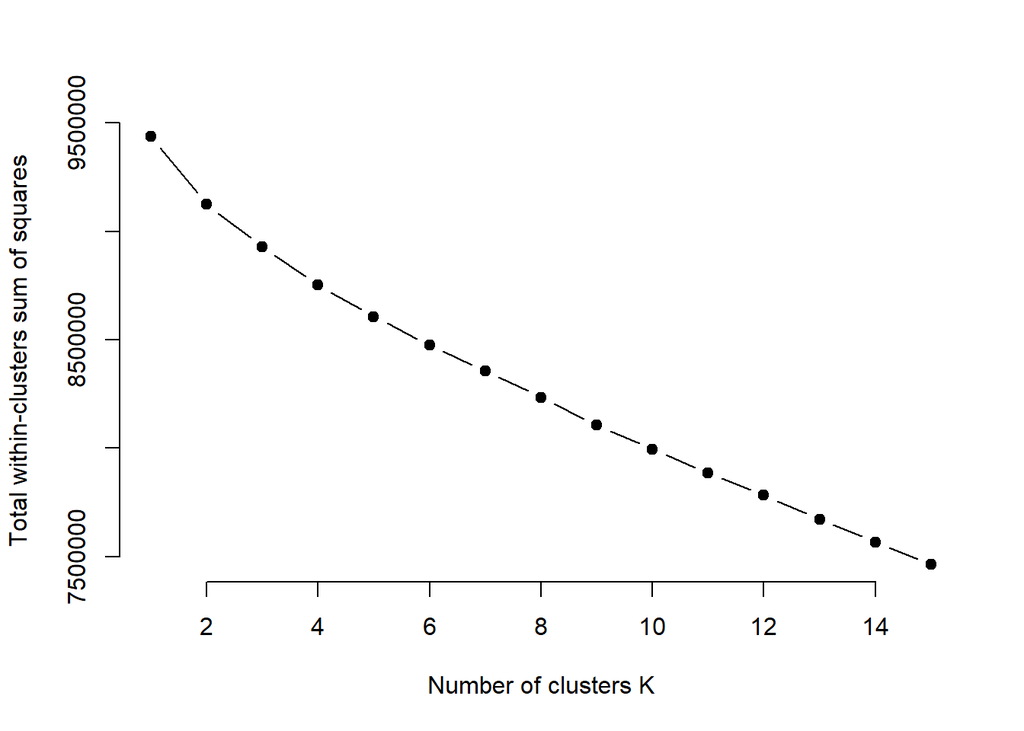

```r
library(purrr)

# function to compute total within-cluster sum of square
wss <- function(k) {
  kmeans(ind.coord, k, nstart = 10 )$tot.withinss
}

# Compute and plot wss for k = 1 to k = 15
k.values <- 1:15

# extract wss for 2-15 clusters
wss_values <- map_dbl(k.values, wss)

plot(k.values, wss_values,
       type="b", pch = 19, frame = FALSE,
       xlab="Number of clusters K",
       ylab="Total within-clusters sum of squares")
```

## Elbow method (Automatic)

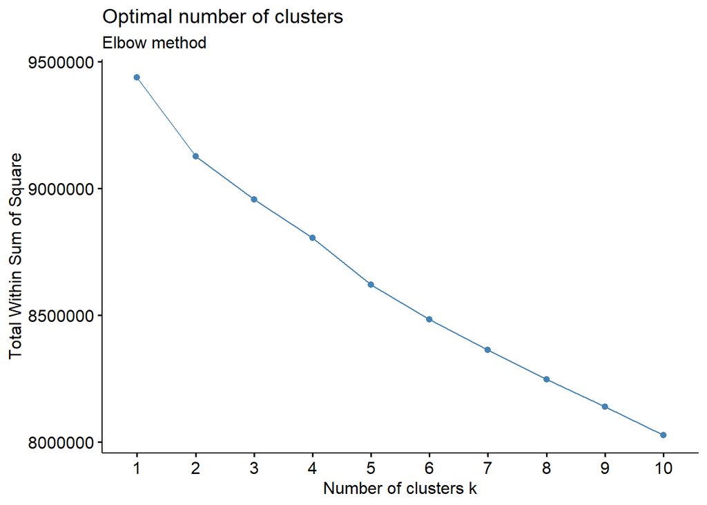

```r
fviz_nbclust(ind.coord, kmeans, method = "wss") +
  labs(subtitle = "Elbow method")
```

# 2. Average Silhouette Method (Manual)

A high average silhouette width indicates a good clustering. The average silhouette method computes the average silhouette of observations for different values of k. The optimal number of clusters k is the one that maximizes the average silhouette over a range of possible values for k.

```r
library(cluster)
```

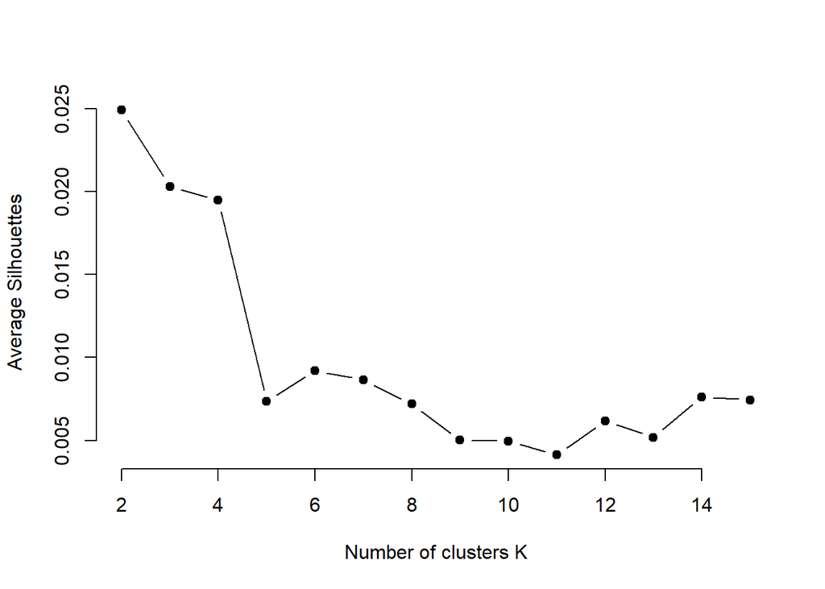

```r
# function to compute average silhouette for k clusters
avg_sil <- function(k) {
  km.res <- kmeans(ind.coord, centers = k, nstart = 25)
  ss <- silhouette(km.res$cluster, dist(ind.coord))
  mean(ss[, 3])
}

# Compute and plot wss for k = 2 to k = 15
k.values <- 2:15

# extract avg silhouette for 2-15 clusters
avg_sil_values <- map_dbl(k.values, avg_sil)

plot(k.values, avg_sil_values,
       type = "b", pch = 19, frame = FALSE,
       xlab = "Number of clusters K",
       ylab = "Average Silhouettes")
```

## Average silhouette (Automatic)

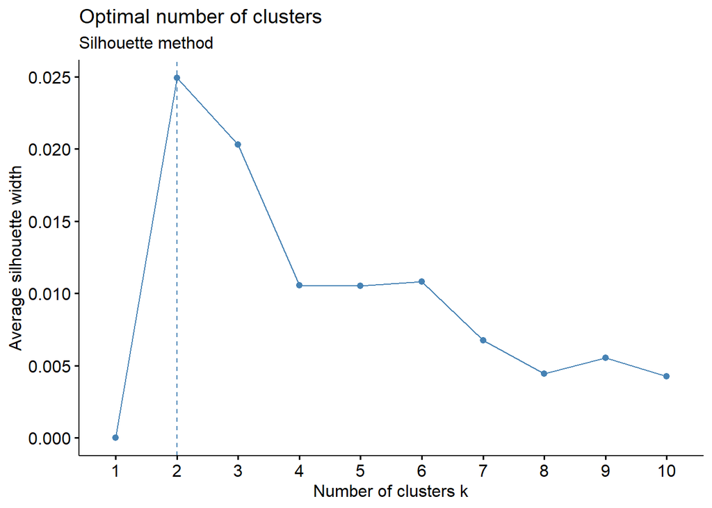

```r
fviz_nbclust(ind.coord, kmeans, method = "silhouette")+
  labs(subtitle = "Silhouette method")
```

#3. Gap Statistic Method

```r
# compute gap statistic
gap_stat <- clusGap(ind.coord, FUN = kmeans, nstart = 25,
                    K.max = 10, B = 50)
# Print the result
print(gap_stat, method = "firstmax")
```

```
## Clustering Gap statistic ["clusGap"] from call:
## clusGap(x = ind.coord, FUNcluster = kmeans, K.max = 10, B = 50,     nstart = 25)
## B=50 simulated reference sets, k = 1..10; spaceH0="scaledPCA"
##  --> Number of clusters (method 'firstmax'): 1
##           logW   E.logW       gap      SE.sim
##  [1,] 9.356263 9.883951 0.5276882 0.004667487
##  [2,] 9.334982 9.859696 0.5247137 0.004486841
##  [3,] 9.319542 9.841779 0.5222363 0.004467016
##  [4,] 9.305418 9.825785 0.5203669 0.004358520
##  [5,] 9.292240 9.811007 0.5187667 0.004311898
##  [6,] 9.280486 9.796783 0.5162972 0.004298381
##  [7,] 9.268256 9.783095 0.5148390 0.004283805
##  [8,] 9.256205 9.769728 0.5135229 0.004332181
##  [9,] 9.243997 9.756479 0.5124820 0.004369631
## [10,] 9.232198 9.743615 0.5114165 0.004355937
```

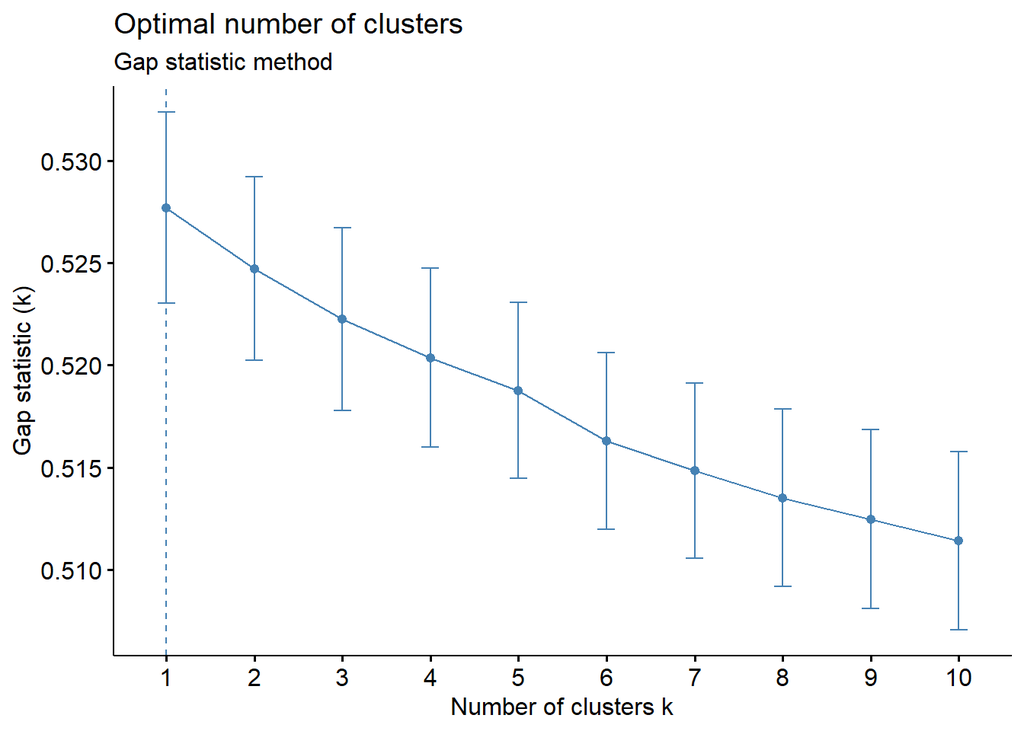

```r
# We visualize the K value suggestion for this method
fviz_gap_stat(gap_stat) +
  labs(subtitle = "Gap statistic method")
```

# Results

With most of these approaches suggesting 2 as the number of optimal clusters, we can perform the final analysis and extract the results using 2 clusters.

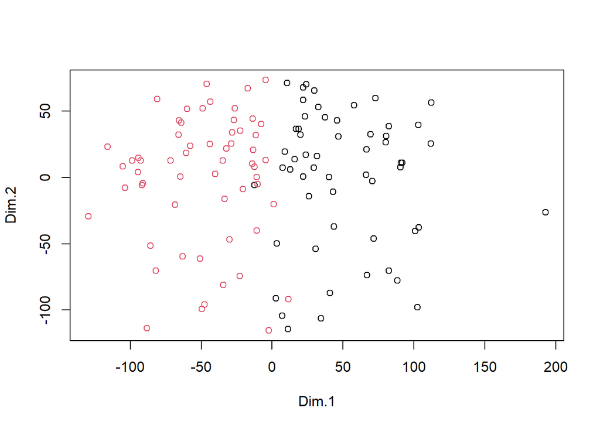

```r
kc <- kmeans(ind.coord, centers = 2, nstart = 25)

plot(ind.coord[,1:2],col=factor(kc$cluster))
```

```r
# Add clusters obtained using the K-means algorithm
ind.coord$cluster <- factor(kc$cluster)
```

```r
# Percentage of variance explained by dimensions
eigenvalue <- round(get_eigenvalue(x), 1)
variance.percent <- eigenvalue$variance.percent

head(eigenvalue)
```

```
##       eigenvalue variance.percent cumulative.variance.percent
## Dim.1     3760.7              4.5                         4.5
## Dim.2     2447.8              3.0                         7.5
## Dim.3     2124.6              2.6                        10.1
## Dim.4     1999.4              2.4                        12.5
## Dim.5     1603.8              1.9                        14.4
## Dim.6     1571.8              1.9                        16.3
```

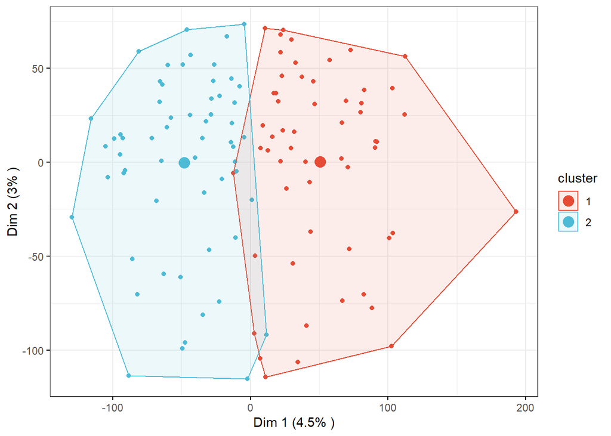

```r
library(ggpubr)

ggscatter(
  ind.coord, x = "Dim.1", y = "Dim.2",
  color = "cluster", palette = "npg", ellipse = TRUE, ellipse.type = "convex", size = 1.5,  legend = "right", ggtheme = theme_bw(),
  xlab = paste0("Dim 1 (", variance.percent[1], "% )" ),
  ylab = paste0("Dim 2 (", variance.percent[2], "% )" )
) +
  stat_mean(aes(color = cluster), size = 4)
```

# Comparing the results with different K values

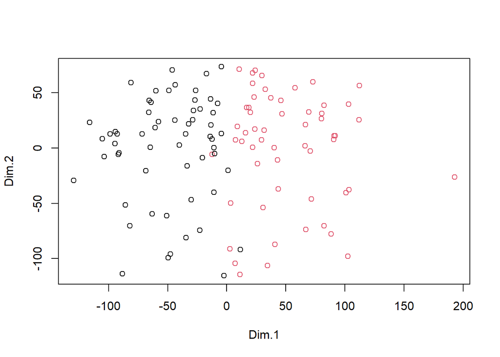

```r
ind.coord_k2 <- ind.coord
ind.coord_k3 <- ind.coord
ind.coord_k4 <- ind.coord
ind.coord_k5 <- ind.coord

k2 <- kmeans(ind.coord_k2, centers = 2, nstart = 25)
k3 <- kmeans(ind.coord_k3, centers = 3, nstart = 25)
k4 <- kmeans(ind.coord_k4, centers = 4, nstart = 25)
k5 <- kmeans(ind.coord_k5, centers = 5, nstart = 25)

# Add clusters obtained using the K-means algorithm
ind.coord_k2$cluster <- factor(k2$cluster)
ind.coord_k3$cluster <- factor(k3$cluster)
ind.coord_k4$cluster <- factor(k4$cluster)
ind.coord_k5$cluster <- factor(k5$cluster)



# plots to compare
plot(ind.coord[,1:2],col=factor(k2$cluster))
```

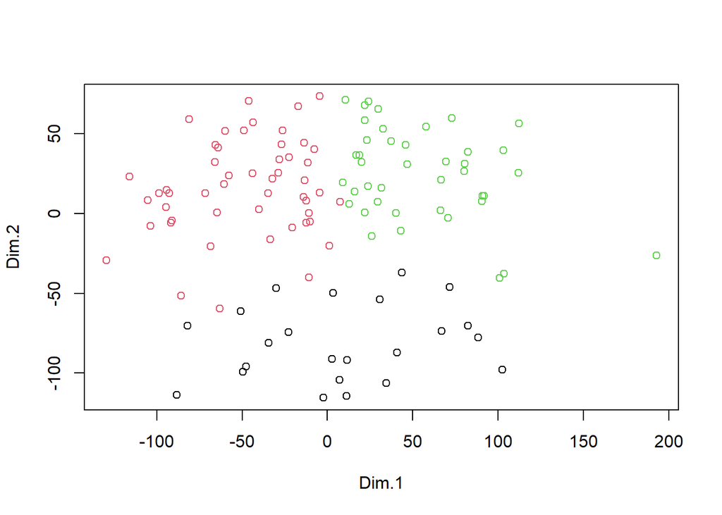

```r
plot(ind.coord[,1:2],col=factor(k3$cluster))
```

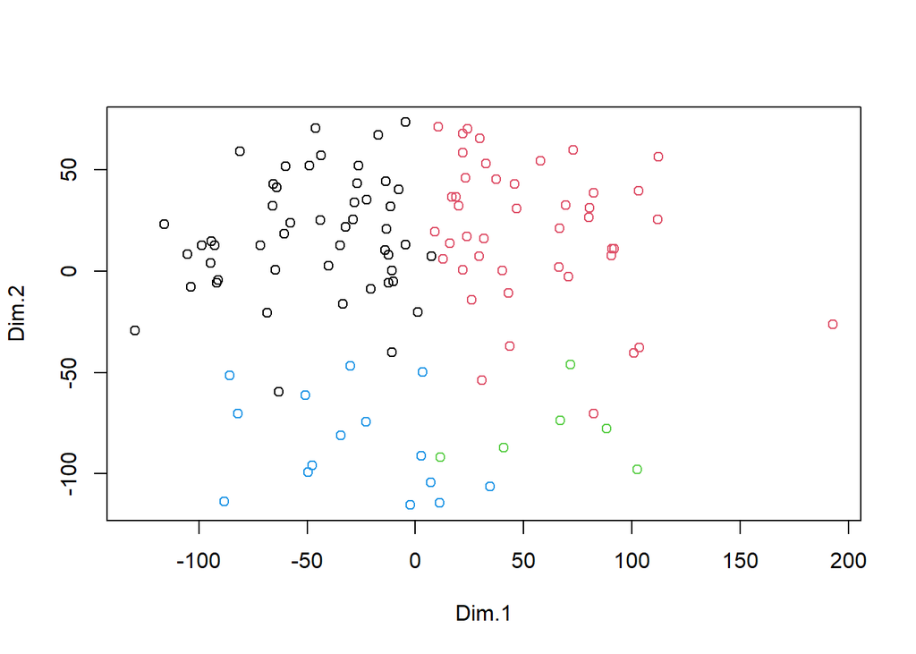

```r
plot(ind.coord[,1:2],col=factor(k4$cluster))
```

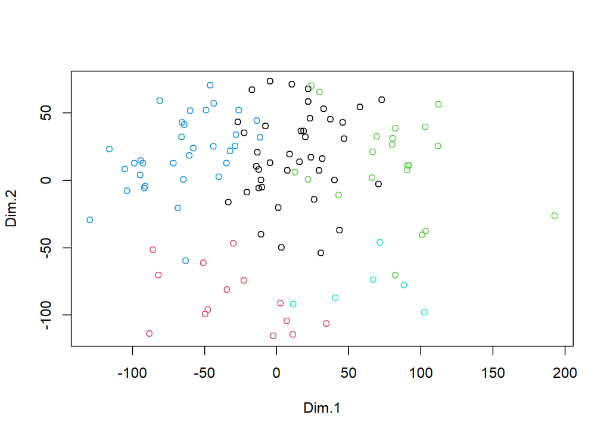

```r
plot(ind.coord[,1:2],col=factor(k5$cluster))
```

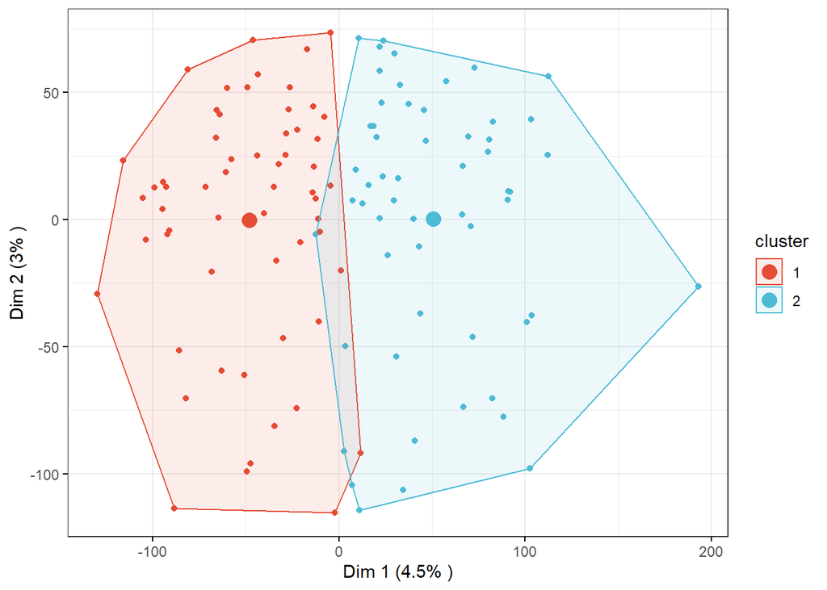

```r
ggscatter(
  ind.coord_k2, x = "Dim.1", y = "Dim.2",
  color = "cluster", palette = "npg", ellipse = TRUE, ellipse.type = "convex", size = 1.5,  legend = "right", ggtheme = theme_bw(),
  xlab = paste0("Dim 1 (", variance.percent[1], "% )" ),
  ylab = paste0("Dim 2 (", variance.percent[2], "% )" )
) +
  stat_mean(aes(color = cluster), size = 4)
```

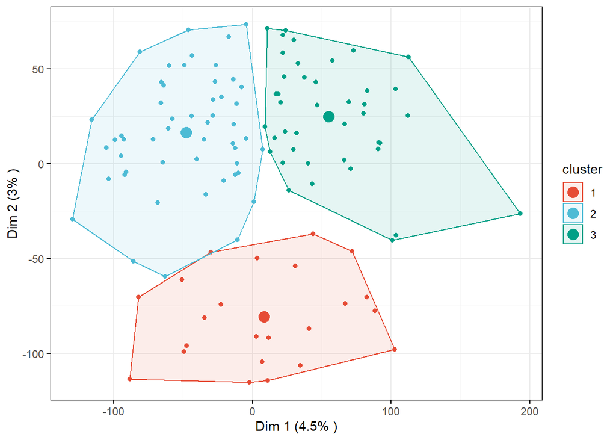

```r
ggscatter(
  ind.coord_k3, x = "Dim.1", y = "Dim.2",
  color = "cluster", palette = "npg", ellipse = TRUE, ellipse.type = "convex", size = 1.5,  legend = "right", ggtheme = theme_bw(),
  xlab = paste0("Dim 1 (", variance.percent[1], "% )" ),
  ylab = paste0("Dim 2 (", variance.percent[2], "% )" )
) +
  stat_mean(aes(color = cluster), size = 4)
```

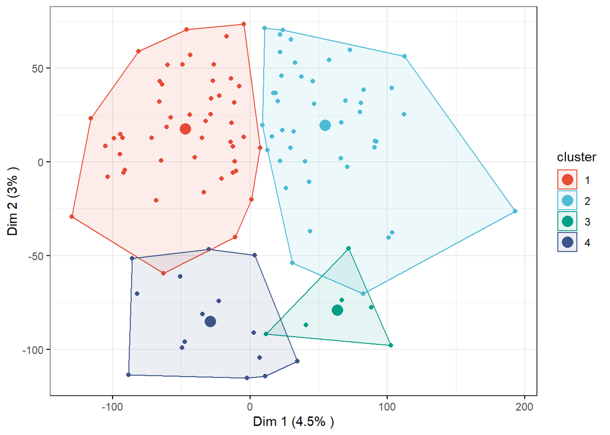

```r
ggscatter(
  ind.coord_k4, x = "Dim.1", y = "Dim.2",
  color = "cluster", palette = "npg", ellipse = TRUE, ellipse.type = "convex", size = 1.5,  legend = "right", ggtheme = theme_bw(),
  xlab = paste0("Dim 1 (", variance.percent[1], "% )" ),
  ylab = paste0("Dim 2 (", variance.percent[2], "% )" )
) +
  stat_mean(aes(color = cluster), size = 4)
```

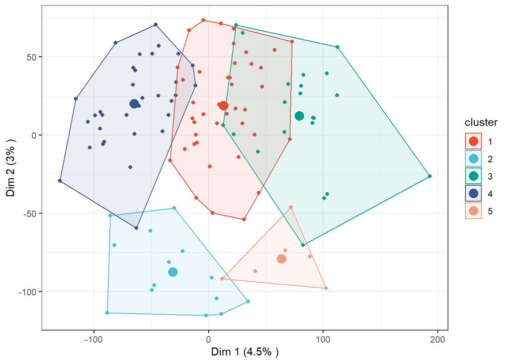

```r
ggscatter(
  ind.coord_k5, x = "Dim.1", y = "Dim.2",
  color = "cluster", palette = "npg", ellipse = TRUE, ellipse.type = "convex", size = 1.5,  legend = "right", ggtheme = theme_bw(),
  xlab = paste0("Dim 1 (", variance.percent[1], "% )" ),
  ylab = paste0("Dim 2 (", variance.percent[2], "% )" )
) +
  stat_mean(aes(color = cluster), size = 4)
```